# Lecture4_Rcode

Nemanja Vaci

March 3, 2021

This is newly added code for simulation. I used faux package to simulate correlated variables.

```r
#install.packages('faux')
require(faux)
set.seed(456) #seed specification for the data simulation

#Here I am specifying a correlation matrix for 6 variables. The correlation matrix has 6*6 = 36 values and codes all correlations for variable-by-variable relations. The first value in the first row is correlation of var1 with itself, then we go to var1-var2, var1-var3,... Second row starts with the var2-var1, then var2-var2...

cmat <- c(1, .4,.4, .1, .1, .1,
          .4, 1,.3, .1, .1, .1,
          .4,.2, 1, .1, .1, .1,
          .1,.1,.1,  1, .4, .4,
          .1,.1,.1, .4,  1, .2,
          .1,.1,.1, .4, .2,  1)

vars<-rnorm_multi(n=100, 6,30,5,cmat) # now we take that correlation matrix and simulate 6 variables with 100 values with mean of 30 and sd of 5.

names(vars)=c('TimeOnTummy','PreciseLegMoves','PreciseHandMoves','Babbling','Screeching','VocalImitation') #Naming of the columns in the vars dataset.

Babies=cbind(Babies,vars) #combination of Babies data set with new variables. Cbind (Column bind) function adds new columns to Babies dataset.
```

```r
options(digits=3) #specifying how many digits should my R print out
head(Babies[,8:13]) #printing first six observations of my Babies dataset, but only for variables that are position in my dataset from 8th to 13th position
```

```
##   TimeOnTummy PreciseLegMoves PreciseHandMoves Babbling Screeching
## 1        27.6            21.2             27.9     26.0       26.1
## 2        28.6            31.8             29.5     35.4       29.7
## 3        32.7            30.6             34.7     33.7       31.0
## 4        22.8            33.4             20.8     22.5       29.9
## 5        31.9            30.8             32.5     26.3       22.4
## 6        30.3            25.1             23.7     35.7       33.1
##   VocalImitation
## 1           27.9
## 2           36.4
## 3           30.9
## 4           27.4
## 5           21.9
## 6           26.4
```

CFA model:

```r
#install.packages('lavaan')
require(lavaan) #package for our cfa function
model1<-'
motor =~ TimeOnTummy + PreciseLegMoves + PreciseHandMoves
verbal =~ Babbling + Screeching + VocalImitation
' # our motor LV is regressed onto TimeOnTummy, PreciseLegMoves and PreciseHandMoves, while our verbal LV is regressed onto Babbling, Screeching and VocalImitation. We used reflective coding =~ for LVs indicating that we assume that our LV is causing/influencing behaviour measured in our dataset.

fit1<-cfa(model1, data=Babies) #fitting the model
summary(fit1) #summary of the results
```

```
## lavaan 0.6-7 ended normally after 74 iterations
##
##   Estimator                                         ML
##   Optimization method                           NLMINB
##   Number of free parameters                         13
##
##   Number of observations                           100
##
## Model Test User Model:
##
##   Test statistic                                 3.376
##   Degrees of freedom                                 8
##   P-value (Chi-square)                           0.909
##
## Parameter Estimates:
##
##   Standard errors                             Standard
##   Information                                 Expected
##   Information saturated (h1) model          Structured
##
## Latent Variables:
##                    Estimate  Std.Err  z-value  P(>|z|)
##   motor =~
##     TimeOnTummy       1.000
##     PreciseLegMovs    0.910    0.240    3.791    0.000
##     PreciseHandMvs    1.099    0.293    3.746    0.000
##   verbal =~
##     Babbling          1.000
##     Screeching        0.494    0.182    2.718    0.007
##     VocalImitation    0.716    0.246    2.906    0.004
##
## Covariances:
##                    Estimate  Std.Err  z-value  P(>|z|)
##   motor ~~
##     verbal            3.433    1.901    1.806    0.071
##
## Variances:
##                    Estimate  Std.Err  z-value  P(>|z|)
##    .TimeOnTummy      15.031    3.181    4.725    0.000
##    .PreciseLegMovs   14.709    2.867    5.130    0.000
##    .PreciseHandMvs   12.515    3.338    3.749    0.000
##    .Babbling          8.805    5.149    1.710    0.087
##    .Screeching       17.139    2.748    6.236    0.000
##    .VocalImitation   16.742    3.514    4.764    0.000
##     motor             9.523    3.625    2.627    0.009
##     verbal           15.635    5.947    2.629    0.009
```

```r
summary(fit1, standardized=TRUE) #with standardised values
```

```
## lavaan 0.6-7 ended normally after 74 iterations
##
##   Estimator                                         ML
##   Optimization method                           NLMINB
##   Number of free parameters                         13
##
##   Number of observations                           100
##
## Model Test User Model:
##
##   Test statistic                                 3.376
##   Degrees of freedom                                 8
##   P-value (Chi-square)                           0.909
##
## Parameter Estimates:
##
##   Standard errors                             Standard
##   Information                                 Expected
##   Information saturated (h1) model          Structured
##
## Latent Variables:
##                    Estimate  Std.Err  z-value  P(>|z|)   Std.lv  Std.all
##   motor =~
##     TimeOnTummy       1.000                               3.086    0.623
##     PreciseLegMovs    0.910    0.240    3.791    0.000    2.807    0.591
##     PreciseHandMvs    1.099    0.293    3.746    0.000    3.392    0.692
##   verbal =~
##     Babbling          1.000                               3.954    0.800
##     Screeching        0.494    0.182    2.718    0.007    1.952    0.426
##     VocalImitation    0.716    0.246    2.906    0.004    2.832    0.569
##
## Covariances:
##                    Estimate  Std.Err  z-value  P(>|z|)   Std.lv  Std.all
##   motor ~~
##     verbal            3.433    1.901    1.806    0.071    0.281    0.281
##
## Variances:
##                    Estimate  Std.Err  z-value  P(>|z|)   Std.lv  Std.all
##    .TimeOnTummy      15.031    3.181    4.725    0.000   15.031    0.612
##    .PreciseLegMovs   14.709    2.867    5.130    0.000   14.709    0.651
##    .PreciseHandMvs   12.515    3.338    3.749    0.000   12.515    0.521
##    .Babbling          8.805    5.149    1.710    0.087    8.805    0.360
##    .Screeching       17.139    2.748    6.236    0.000   17.139    0.818
##    .VocalImitation   16.742    3.514    4.764    0.000   16.742    0.676
##     motor             9.523    3.625    2.627    0.009    1.000    1.000
##     verbal           15.635    5.947    2.629    0.009    1.000    1.000
```

Model 2, scaling the factors by seting variance to 1:

```r
model2<-'
motor =~ NA*TimeOnTummy + PreciseLegMoves + PreciseHandMoves
verbal =~ NA*Babbling + Screeching + VocalImitation
motor ~~ 1*motor
verbal ~~ 1*verbal
'
# In this situation we used same specification of the latent factors, but we change the way how the scale of latent variables is defined. We are defining the scale by seting variance of LVs to 1, this is done with motor ~~ 1*motor and verbal ~~ 1*verbal. We also include NA* to two first variables (that are always used to scale LVs) that we would like to estimate.

fit2<-cfa(model2, data=Babies)
summary(fit2, standardized=TRUE)
```

```
## lavaan 0.6-7 ended normally after 33 iterations
##
##   Estimator                                         ML
##   Optimization method                           NLMINB
##   Number of free parameters                         13
##
##   Number of observations                           100
##
## Model Test User Model:
##
##   Test statistic                                 3.376
##   Degrees of freedom                                 8
##   P-value (Chi-square)                           0.909
##
## Parameter Estimates:
##
##   Standard errors                             Standard
##   Information                                 Expected
##   Information saturated (h1) model          Structured
##
## Latent Variables:
##                    Estimate  Std.Err  z-value  P(>|z|)   Std.lv  Std.all
##   motor =~
##     TimeOnTummy       3.086    0.587    5.254    0.000    3.086    0.623
##     PreciseLegMovs    2.807    0.557    5.042    0.000    2.807    0.591
##     PreciseHandMvs    3.392    0.597    5.680    0.000    3.392    0.692
##   verbal =~
##     Babbling          3.954    0.752    5.259    0.000    3.954    0.800
##     Screeching        1.952    0.548    3.560    0.000    1.952    0.426
##     VocalImitation    2.832    0.646    4.381    0.000    2.832    0.569
##
## Covariances:
##                    Estimate  Std.Err  z-value  P(>|z|)   Std.lv  Std.all
##   motor ~~
##     verbal            0.281    0.139    2.028    0.043    0.281    0.281
##
## Variances:
##                    Estimate  Std.Err  z-value  P(>|z|)   Std.lv  Std.all
##     motor             1.000                               1.000    1.000
##     verbal            1.000                               1.000    1.000
##    .TimeOnTummy      15.031    3.181    4.725    0.000   15.031    0.612
##    .PreciseLegMovs   14.709    2.867    5.130    0.000   14.709    0.651
##    .PreciseHandMvs   12.515    3.338    3.749    0.000   12.515    0.521
##    .Babbling          8.805    5.149    1.710    0.087    8.805    0.360
##    .Screeching       17.139    2.748    6.236    0.000   17.139    0.818
##    .VocalImitation   16.742    3.514    4.764    0.000   16.742    0.676
```

Adding intercepts to our model:

```r
model3<-'
motor =~ TimeOnTummy + PreciseLegMoves + PreciseHandMoves
verbal =~ Babbling + Screeching + VocalImitation
TimeOnTummy ~ 1
PreciseLegMoves ~ 1
PreciseHandMoves ~ 1
Babbling ~ 1
Screeching ~ 1
VocalImitation ~ 1'
# Model stays again identical to the first one (scaled by the measure of first variables), however we add TimeOnTummy ~ 1 and this is identical for all measured variables.
fit3<-cfa(model3, data=Babies)
summary(fit3, standardized=TRUE, fit.measures=T)
```

```
## lavaan 0.6-7 ended normally after 74 iterations
##
##   Estimator                                         ML
##   Optimization method                           NLMINB
##   Number of free parameters                         19
##
##   Number of observations                           100
##
## Model Test User Model:
##
##   Test statistic                                 3.376
##   Degrees of freedom                                 8
##   P-value (Chi-square)                           0.909
##
## Model Test Baseline Model:
##
##   Test statistic                                88.357
##   Degrees of freedom                                15
##   P-value                                        0.000
##
## User Model versus Baseline Model:
##
##   Comparative Fit Index (CFI)                    1.000
##   Tucker-Lewis Index (TLI)                       1.118
##
## Loglikelihood and Information Criteria:
##
##   Loglikelihood user model (H0)              -1756.127
##   Loglikelihood unrestricted model (H1)      -1754.439
##
##   Akaike (AIC)                                3550.253
##   Bayesian (BIC)                              3599.751
##   Sample-size adjusted Bayesian (BIC)         3539.744
##
## Root Mean Square Error of Approximation:
##
##   RMSEA                                          0.000
##   90 Percent confidence interval - lower         0.000
##   90 Percent confidence interval - upper         0.047
##   P-value RMSEA <= 0.05                          0.954
```

[output cut: 33 more lines]

```
##    .Screeching       29.785    0.458   65.078    0.000   29.785    6.508
##    .VocalImitation   30.409    0.498   61.110    0.000   30.409    6.111
##     motor             0.000                               0.000    0.000
##     verbal            0.000                               0.000    0.000
##
## Variances:
##                    Estimate  Std.Err  z-value  P(>|z|)   Std.lv  Std.all
##    .TimeOnTummy      15.031    3.181    4.725    0.000   15.031    0.612
##    .PreciseLegMovs   14.709    2.867    5.130    0.000   14.709    0.651
##    .PreciseHandMvs   12.515    3.338    3.749    0.000   12.515    0.521
##    .Babbling          8.805    5.149    1.710    0.087    8.805    0.360
##    .Screeching       17.139    2.748    6.236    0.000   17.139    0.818
##    .VocalImitation   16.742    3.514    4.764    0.000   16.742    0.676
##     motor             9.523    3.625    2.627    0.009    1.000    1.000
##     verbal           15.635    5.947    2.629    0.009    1.000    1.000
```

Variance-covariance matrix

```r
cov(Babies[,8:13]) #covariance for Babies data frame, for columns from 8 to 13
```

```
##                  TimeOnTummy PreciseLegMoves PreciseHandMoves Babbling
## TimeOnTummy           24.802            8.82            10.85     1.35
## PreciseLegMoves        8.822           22.82             9.27     4.04
## PreciseHandMoves      10.853            9.27            24.27     3.52
## Babbling               1.353            4.04             3.52    24.69
## Screeching             0.589            3.12             1.72     8.08
## VocalImitation         2.715            4.46             4.33    11.31
##                  Screeching VocalImitation
## TimeOnTummy           0.589           2.71
## PreciseLegMoves       3.116           4.46
## PreciseHandMoves      1.720           4.33
## Babbling              8.081          11.31
## Screeching           21.159           4.81
## VocalImitation        4.809          25.01
```

Indices of global model fit

```r
summary(fit1, fit.measures=TRUE)
```

```
## lavaan 0.6-7 ended normally after 74 iterations
##
##   Estimator                                         ML
##   Optimization method                           NLMINB
##   Number of free parameters                         13
##
##   Number of observations                           100
##
## Model Test User Model:
##
##   Test statistic                                 3.376
##   Degrees of freedom                                 8
##   P-value (Chi-square)                           0.909
##
## Model Test Baseline Model:
##
##   Test statistic                                88.357
##   Degrees of freedom                                15
##   P-value                                        0.000
##
## User Model versus Baseline Model:
##
##   Comparative Fit Index (CFI)                    1.000
##   Tucker-Lewis Index (TLI)                       1.118
##
## Loglikelihood and Information Criteria:
##
##   Loglikelihood user model (H0)              -1756.127
##   Loglikelihood unrestricted model (H1)      -1754.439
##
##   Akaike (AIC)                                3538.253
##   Bayesian (BIC)                              3572.120
##   Sample-size adjusted Bayesian (BIC)         3531.063
##
## Root Mean Square Error of Approximation:
##
##   RMSEA                                          0.000
##   90 Percent confidence interval - lower         0.000
##   90 Percent confidence interval - upper         0.047
##   P-value RMSEA <= 0.05                          0.954
```

[output cut: 22 more lines]

```
## Covariances:
##                    Estimate  Std.Err  z-value  P(>|z|)
##   motor ~~
##     verbal            3.433    1.901    1.806    0.071
##
## Variances:
##                    Estimate  Std.Err  z-value  P(>|z|)
##    .TimeOnTummy      15.031    3.181    4.725    0.000
##    .PreciseLegMovs   14.709    2.867    5.130    0.000
##    .PreciseHandMvs   12.515    3.338    3.749    0.000
##    .Babbling          8.805    5.149    1.710    0.087
##    .Screeching       17.139    2.748    6.236    0.000
##    .VocalImitation   16.742    3.514    4.764    0.000
##     motor             9.523    3.625    2.627    0.009
##     verbal           15.635    5.947    2.629    0.009
```

Full structural equation model (combination between the Path and CFA model):

```r
model4<-'
#CFA model
motor =~ TimeOnTummy + PreciseLegMoves + PreciseHandMoves
verbal =~ Babbling + Screeching + VocalImitation

#Path model
motor ~ Age + Weight
verbal ~ Age + Weight
'

fit4<-sem(model4, data=Babies)
summary(fit4, standardized=TRUE)
```

```
## lavaan 0.6-7 ended normally after 81 iterations
##
##   Estimator                                         ML
##   Optimization method                           NLMINB
##   Number of free parameters                         17
##
##   Number of observations                           100
##
## Model Test User Model:
##
##   Test statistic                                13.018
##   Degrees of freedom                                16
##   P-value (Chi-square)                           0.671
##
## Parameter Estimates:
##
##   Standard errors                             Standard
##   Information                                 Expected
##   Information saturated (h1) model          Structured
##
## Latent Variables:
##                    Estimate    Std.Err  z-value  P(>|z|)   Std.lv    Std.all
##   motor =~
##     TimeOnTummy         1.000                                 3.064    0.618
##     PreciseLegMovs      0.919    0.242    3.803    0.000      2.816    0.592
##     PreciseHandMvs      1.111    0.295    3.765    0.000      3.403    0.694
##   verbal =~
##     Babbling            1.000                                 3.498    0.708
##     Screeching          0.583    0.189    3.089    0.002      2.040    0.446
##     VocalImitation      0.899    0.263    3.422    0.001      3.144    0.632
##
## Regressions:
##                    Estimate    Std.Err  z-value  P(>|z|)   Std.lv    Std.all
##   motor ~
##     Age                -0.016    0.045   -0.355    0.723     -0.005   -0.043
##     Weight              0.000    0.001    0.085    0.932      0.000    0.010
##   verbal ~
##     Age                -0.041    0.051   -0.803    0.422     -0.012   -0.097
##     Weight              0.002    0.001    2.108    0.035      0.001    0.263
##
## Covariances:
##                    Estimate    Std.Err  z-value  P(>|z|)   Std.lv    Std.all
##  .motor ~~
##    .verbal              3.292    1.738    1.894    0.058      0.320    0.320
##
## Variances:
##                    Estimate    Std.Err  z-value  P(>|z|)   Std.lv    Std.all
##    .TimeOnTummy        15.164    3.159    4.800    0.000     15.164    0.618
##    .PreciseLegMovs     14.662    2.862    5.122    0.000     14.662    0.649
##    .PreciseHandMvs     12.440    3.327    3.740    0.000     12.440    0.518
##    .Babbling           12.204    3.740    3.263    0.001     12.204    0.499
##    .Screeching         16.784    2.717    6.177    0.000     16.784    0.801
##    .VocalImitation     14.880    3.440    4.326    0.000     14.880    0.601
##    .motor               9.372    3.577    2.620    0.009      0.998    0.998
##    .verbal             11.299    4.205    2.687    0.007      0.923    0.923
```

Full structural equation model 2 (with mediation over height):

```r
model5<-'
#CFA model
motor =~ TimeOnTummy + PreciseLegMoves + PreciseHandMoves
verbal =~ Babbling + Screeching + VocalImitation

#Path model
Height ~ Age
motor ~ Age + Weight + Height
verbal ~ Age + Weight + Height
'

fit5<-sem(model5, data=Babies)
summary(fit5, standardized=TRUE)
```

```
## lavaan 0.6-7 ended normally after 83 iterations
##
##   Estimator                                         ML
##   Optimization method                           NLMINB
##   Number of free parameters                         21
##
##   Number of observations                           100
##
## Model Test User Model:
##
##   Test statistic                                36.805
##   Degrees of freedom                                21
##   P-value (Chi-square)                           0.018
##
## Parameter Estimates:
##
##   Standard errors                             Standard
##   Information                                 Expected
##   Information saturated (h1) model          Structured
##
## Latent Variables:
##                    Estimate    Std.Err  z-value  P(>|z|)   Std.lv    Std.all
##   motor =~
##     TimeOnTummy         1.000                                 3.066    0.618
##     PreciseLegMovs      0.954    0.248    3.850    0.000      2.924    0.614
##     PreciseHandMvs      1.084    0.283    3.838    0.000      3.324    0.677
##   verbal =~
##     Babbling            1.000                                 3.444    0.687
##     Screeching          0.606    0.182    3.326    0.001      2.089    0.454
##     VocalImitation      0.979    0.251    3.894    0.000      3.371    0.669
##
## Regressions:
##                    Estimate    Std.Err  z-value  P(>|z|)   Std.lv    Std.all
##   Height ~
##     Age                 0.143    0.064    2.251    0.024      0.143    0.220
##   motor ~
##     Age                -0.005    0.046   -0.109    0.914     -0.002   -0.013
##     Weight              0.000    0.001    0.543    0.587      0.000    0.066
##     Height             -0.082    0.072   -1.144    0.253     -0.027   -0.144
##   verbal ~
##     Age                -0.021    0.050   -0.426    0.670     -0.006   -0.051
##     Weight              0.003    0.001    2.817    0.005      0.001    0.349
##     Height             -0.140    0.078   -1.788    0.074     -0.041   -0.218
##
## Covariances:
##                    Estimate    Std.Err  z-value  P(>|z|)   Std.lv    Std.all
##  .motor ~~
##    .verbal              2.976    1.621    1.836    0.066      0.314    0.314
##
## Variances:
##                    Estimate    Std.Err  z-value  P(>|z|)   Std.lv    Std.all
##    .TimeOnTummy        15.221    3.132    4.860    0.000     15.221    0.618
##    .PreciseLegMovs     14.103    2.876    4.904    0.000     14.103    0.623
##    .PreciseHandMvs     13.052    3.217    4.057    0.000     13.052    0.542
##    .Babbling           13.265    3.353    3.957    0.000     13.265    0.528
##    .Screeching         16.837    2.702    6.231    0.000     16.837    0.794
##    .VocalImitation     14.055    3.335    4.215    0.000     14.055    0.553
##    .Height             27.352    3.868    7.071    0.000     27.352    0.952
##    .motor               9.158    3.477    2.634    0.008      0.974    0.974
##    .verbal              9.796    3.520    2.783    0.005      0.826    0.826
```

Configural invariance. Comparison of the model between two or more groups. What we would like to see is whether model behaves differently between these groups. Configural invariance gives us a first look into these differences - whether the overal fit of the model changes when we specify it over groups.

```r
modelMI<-'
motor =~ TimeOnTummy + PreciseLegMoves + PreciseHandMoves
verbal =~ Babbling + Screeching + VocalImitation
'

fitMIC<-cfa(modelMI, data=Babies, group='Gender') # for configural invariance we can specify group gender and leave all other parameters to be unrestricted
summary(fitMIC)
```

```
## lavaan 0.6-7 ended normally after 141 iterations
##
##   Estimator                                         ML
##   Optimization method                           NLMINB
##   Number of free parameters                         38
##
##   Number of observations per group:
##     Girls                                           48
##     Boys                                            52
##
## Model Test User Model:
##
##   Test statistic                                15.880
##   Degrees of freedom                                16
##   P-value (Chi-square)                           0.461
##   Test statistic for each group:
##     Girls                                        6.246
##     Boys                                         9.634
##
## Parameter Estimates:
##
##   Standard errors                             Standard
##   Information                                 Expected
##   Information saturated (h1) model          Structured
##
##
## Group 1 [Girls]:
##
## Latent Variables:
##                    Estimate  Std.Err  z-value  P(>|z|)
##   motor =~
##     TimeOnTummy       1.000
##     PreciseLegMovs    0.754    0.282    2.677    0.007
##     PreciseHandMvs    0.982    0.345    2.849    0.004
##   verbal =~
##     Babbling          1.000
##     Screeching        0.428    0.237    1.809    0.070
##     VocalImitation    0.632    0.313    2.021    0.043
##
## Covariances:
```

[output cut: 51 more lines]

```
##    .Screeching       30.251    0.620   48.790    0.000
##    .VocalImitation   29.962    0.655   45.744    0.000
##     motor             0.000
##     verbal            0.000
##
## Variances:
##                    Estimate  Std.Err  z-value  P(>|z|)
##    .TimeOnTummy      13.783    3.710    3.715    0.000
##    .PreciseLegMovs    9.737    3.951    2.465    0.014
##    .PreciseHandMvs   13.963    4.139    3.373    0.001
##    .Babbling         -0.009    9.707   -0.001    0.999
##    .Screeching       16.649    3.652    4.559    0.000
##    .VocalImitation   16.035    4.395    3.649    0.000
##     motor             7.101    3.990    1.779    0.075
##     verbal           19.837   10.457    1.897    0.058
```

```r
modelMI<-'
motor =~ TimeOnTummy + PreciseLegMoves + PreciseHandMoves
verbal =~ Babbling + Screeching + VocalImitation
'

fitMIM<-cfa(modelMI, data=Babies, group='Gender',group.equal='loadings') #we restrict the loadings on factors between two groups.
summary(fitMIM)
```

```
## lavaan 0.6-7 ended normally after 135 iterations
##
##   Estimator                                         ML
##   Optimization method                           NLMINB
##   Number of free parameters                         38
##   Number of equality constraints                     4
##
##   Number of observations per group:
##     Girls                                           48
##     Boys                                            52
##
## Model Test User Model:
##
##   Test statistic                                16.556
##   Degrees of freedom                                20
##   P-value (Chi-square)                           0.682
##   Test statistic for each group:
##     Girls                                        6.606
##     Boys                                         9.951
##
## Parameter Estimates:
##
##   Standard errors                             Standard
##   Information                                 Expected
##   Information saturated (h1) model          Structured
##
##
## Group 1 [Girls]:
##
## Latent Variables:
##                    Estimate  Std.Err  z-value  P(>|z|)
##   motor =~
##     TmOnTmm           1.000
##     PrcsLgM (.p2.)    0.949    0.247    3.840    0.000
##     PrcsHnM (.p3.)    1.037    0.267    3.880    0.000
##   verbal =~
##     Babblng           1.000
##     Scrchng (.p5.)    0.430    0.164    2.619    0.009
##     VclImtt (.p6.)    0.601    0.211    2.854    0.004
##
```

[output cut: 52 more lines]

```
##    .Screeching       30.251    0.619   48.885    0.000
##    .VocalImitation   29.962    0.657   45.613    0.000
##     motor             0.000
##     verbal            0.000
##
## Variances:
##                    Estimate  Std.Err  z-value  P(>|z|)
##    .TimeOnTummy      12.951    3.622    3.576    0.000
##    .PreciseLegMovs   11.037    3.171    3.481    0.000
##    .PreciseHandMvs   13.593    3.843    3.537    0.000
##    .Babbling          1.076    6.336    0.170    0.865
##    .Screeching       16.449    3.442    4.779    0.000
##    .VocalImitation   15.667    3.841    4.079    0.000
##     motor             8.566    3.646    2.349    0.019
##     verbal           18.747    7.377    2.541    0.011
```

```r
#install.packages('semTools')
require(semTools)
summary(compareFit(fitMIC, fitMIM)) # compareFit compares our two models and gives as an information of whether one is worse than the other. If model with restricted loadings is worse that is an indication that loadings are different.
```

```
## ################### Nested Model Comparison #########################
## Chi-Squared Difference Test
##
##        Df  AIC  BIC Chisq Chisq diff Df diff Pr(>Chisq)
## fitMIC 16 3573 3672  15.9
## fitMIM 20 3566 3655  16.6      0.677       4       0.95
##
## ####################### Model Fit Indices ###########################
##          chisq df pvalue    cfi    tli       aic       bic rmsea  srmr
## fitMIC 15.880† 16   .461 1.000† 1.003  3573.335  3672.332  .000† .065
## fitMIM 16.556  20   .682 1.000† 1.067† 3566.012† 3654.588† .000† .064†
##
## ################## Differences in Fit Indices #######################
##                 df cfi   tli   aic   bic rmsea   srmr
## fitMIM - fitMIC  4   0 0.064 -7.32 -17.7     0 -0.001
```

Scalar invariance. In the case of scalar invariance we would like to restrict both loadings and intercepts between two groups. Similar to the previous two invariances, when we compare the models if the scalar invariance model fits worse than metric invariance or configural invariance, then we can assume that intercepts or means are not identical between the groups.

```r
modelMI<-'
motor =~ TimeOnTummy + PreciseLegMoves + PreciseHandMoves
verbal =~ Babbling + Screeching + VocalImitation
'

fitMISc<-cfa(modelMI, data=Babies, group='Gender',group.equal=c('loadings','intercepts')) #Restriction of the loadings and intercepts
summary(fitMISc)
```

```
## lavaan 0.6-7 ended normally after 153 iterations
##
##   Estimator                                         ML
##   Optimization method                           NLMINB
##   Number of free parameters                         40
##   Number of equality constraints                    10
##
##   Number of observations per group:
##     Girls                                           48
##     Boys                                            52
##
## Model Test User Model:
##
##   Test statistic                                19.394
##   Degrees of freedom                                24
##   P-value (Chi-square)                           0.731
##   Test statistic for each group:
##     Girls                                        8.252
##     Boys                                        11.142
##
## Parameter Estimates:
##
##   Standard errors                             Standard
##   Information                                 Expected
##   Information saturated (h1) model          Structured
##
##
## Group 1 [Girls]:
##
## Latent Variables:
##                    Estimate  Std.Err  z-value  P(>|z|)
##   motor =~
##     TmOnTmm           1.000
##     PrcsLgM (.p2.)    0.949    0.244    3.880    0.000
##     PrcsHnM (.p3.)    1.045    0.266    3.925    0.000
##   verbal =~
##     Babblng           1.000
##     Scrchng (.p5.)    0.410    0.163    2.510    0.012
##     VclImtt (.p6.)    0.560    0.206    2.715    0.007
##
```

[output cut: 52 more lines]

```
##    .Scrchng (.20.)   29.718    0.504   58.930    0.000
##    .VclImtt (.21.)   30.219    0.575   52.515    0.000
##     motor            -0.628    0.766   -0.819    0.413
##     verbal            0.405    0.985    0.411    0.681
##
## Variances:
##                    Estimate  Std.Err  z-value  P(>|z|)
##    .TimeOnTummy      12.970    3.609    3.594    0.000
##    .PreciseLegMovs   11.054    3.159    3.500    0.000
##    .PreciseHandMvs   13.564    3.847    3.526    0.000
##    .Babbling         -0.129    7.015   -0.018    0.985
##    .Screeching       16.806    3.500    4.802    0.000
##    .VocalImitation   16.307    3.880    4.203    0.000
##     motor             8.523    3.612    2.359    0.018
##     verbal           19.957    8.027    2.486    0.013
```

```r
summary(compareFit(fitMIM,fitMISc)) # comparison between measurement invariance and scalar invariance model
```

```
## ################### Nested Model Comparison #########################
## Chi-Squared Difference Test
##
##         Df  AIC  BIC Chisq Chisq diff Df diff Pr(>Chisq)
## fitMIM  20 3566 3655  16.6
## fitMISc 24 3561 3639  19.4       2.84       4       0.59
##
## ####################### Model Fit Indices ###########################
##           chisq df pvalue    cfi    tli       aic       bic rmsea  srmr
## fitMIM  16.556† 20   .682 1.000† 1.067  3566.012  3654.588  .000† .064†
## fitMISc 19.394  24   .731 1.000† 1.074† 3560.850† 3639.005† .000† .071
##
## ################## Differences in Fit Indices #######################
##                  df cfi   tli   aic   bic rmsea  srmr
## fitMISc - fitMIM  4   0 0.008 -5.16 -15.6     0 0.007
```

Strict invariance. Strict invariance restricts loadings, intercepts and error variances. In this case, not only that we are assuming that all direct effects are identical (loadings and intercepts), but we also test whether unexplained variance is identical. This is akin to saying that the same data generating proces and structural effects can be assumed between the two groups.

```r
modelMI<-'
motor =~ TimeOnTummy + PreciseLegMoves + PreciseHandMoves
verbal =~ Babbling + Screeching + VocalImitation
'

fitMISt<-cfa(modelMI, data=Babies, group='Gender',group.equal=c('loadings','intercepts','residuals')) #restricting loadings, intercepts and residuals
summary(fitMISt)
```

```
## lavaan 0.6-7 ended normally after 107 iterations
##
##   Estimator                                         ML
##   Optimization method                           NLMINB
##   Number of free parameters                         40
##   Number of equality constraints                    16
##
##   Number of observations per group:
##     Girls                                           48
##     Boys                                            52
##
## Model Test User Model:
##
##   Test statistic                                25.722
##   Degrees of freedom                                30
##   P-value (Chi-square)                           0.689
##   Test statistic for each group:
##     Girls                                       10.852
##     Boys                                        14.870
##
## Parameter Estimates:
##
##   Standard errors                             Standard
##   Information                                 Expected
##   Information saturated (h1) model          Structured
##
##
## Group 1 [Girls]:
##
## Latent Variables:
##                    Estimate  Std.Err  z-value  P(>|z|)
##   motor =~
##     TmOnTmm           1.000
##     PrcsLgM (.p2.)    0.916    0.237    3.858    0.000
##     PrcsHnM (.p3.)    1.046    0.270    3.872    0.000
##   verbal =~
##     Babblng           1.000
##     Scrchng (.p5.)    0.357    0.152    2.352    0.019
##     VclImtt (.p6.)    0.497    0.194    2.561    0.010
##
```

[output cut: 52 more lines]

```
##    .Scrchng (.20.)   29.700    0.506   58.645    0.000
##    .VclImtt (.21.)   30.290    0.582   52.081    0.000
##     motor            -0.635    0.772   -0.823    0.411
##     verbal            0.459    0.994    0.462    0.644
##
## Variances:
##                    Estimate  Std.Err  z-value  P(>|z|)
##    .TmOnTmm (.p7.)   14.722    3.138    4.691    0.000
##    .PrcsLgM (.p8.)   14.342    2.843    5.045    0.000
##    .PrcsHnM (.p9.)   13.256    3.161    4.194    0.000
##    .Babblng (.10.)    1.930    7.776    0.248    0.804
##    .Scrchng (.11.)   18.072    2.752    6.568    0.000
##    .VclImtt (.12.)   19.193    3.335    5.755    0.000
##     motor             8.157    3.558    2.292    0.022
##     verbal           18.233    8.616    2.116    0.034
```

```r
summary(compareFit(fitMISc,fitMISt)) # model comparison
```

```
## ################### Nested Model Comparison #########################
## Chi-Squared Difference Test
##
##         Df  AIC  BIC Chisq Chisq diff Df diff Pr(>Chisq)
## fitMISc 24 3561 3639  19.4
## fitMISt 30 3555 3618  25.7       6.33       6       0.39
##
## ####################### Model Fit Indices ###########################
##           chisq df pvalue    cfi    tli       aic       bic rmsea  srmr
## fitMISc 19.394† 24   .731 1.000† 1.074† 3560.850  3639.005  .000† .071†
## fitMISt 25.722  30   .689 1.000† 1.055  3555.178† 3617.702† .000† .079
##
## ################## Differences in Fit Indices #######################
##                   df cfi    tli   aic   bic rmsea  srmr
## fitMISt - fitMISc  6   0 -0.019 -5.67 -21.3     0 0.008
```

When you have differences between the models. For example between Measurement invariance and configural invariance model, you would like to see which parameters are different between the groups. You can do that using this function:

```r
lavTestScore(fitMISc)
```

```
## $test
##
## total score test:
##
##    test   X2 df p.value
## 1 score 3.39 10   0.971
##
## $uni
##
## univariate score tests:
##
##      lhs op   rhs    X2 df p.value
## 1   .p2. == .p25. 0.479  1   0.489
## 2   .p3. == .p26. 0.015  1   0.903
## 3   .p5. == .p28. 0.006  1   0.939
## 4   .p6. == .p29. 0.047  1   0.828
## 5  .p16. == .p39. 0.007  1   0.936
## 6  .p17. == .p40. 0.021  1   0.885
## 7  .p18. == .p41. 0.045  1   0.831
## 8  .p19. == .p42. 0.278  1   0.598
## 9  .p20. == .p43. 0.958  1   0.328
## 10 .p21. == .p44. 1.948  1   0.163
```

Modification indices are suggestions from the models when it comes to the paths and relations that you can include to improve the fit of the model (make a better model). They are completely atheoretical and should be used with caution.

```r
mi <- modindices(fit1)
mi[mi$op == "=~"]
```

```
##                 lhs op              rhs    mi    epc sepc.lv
## 16            motor =~         Babbling 0.997 -0.265  -0.817
## 17            motor =~       Screeching 0.001  0.005   0.014
## 18            motor =~   VocalImitation 1.157  0.224   0.690
## 19           verbal =~      TimeOnTummy 1.354 -0.178  -0.705
## 20           verbal =~  PreciseLegMoves 1.061  0.150   0.593
## 21           verbal =~ PreciseHandMoves 0.028  0.026   0.104
## 22      TimeOnTummy ~~  PreciseLegMoves 0.028  0.870   0.870
## 23      TimeOnTummy ~~ PreciseHandMoves 1.061  7.239   7.239
## 24      TimeOnTummy ~~         Babbling 0.811 -1.728  -1.728
## 25      TimeOnTummy ~~       Screeching 0.171 -0.771  -0.771
## 26      TimeOnTummy ~~   VocalImitation 0.019  0.270   0.270
## 27  PreciseLegMoves ~~ PreciseHandMoves 1.354 -7.123  -7.123
## 28  PreciseLegMoves ~~         Babbling 0.038  0.362   0.362
## 29  PreciseLegMoves ~~       Screeching 0.525  1.311   1.311
## 30  PreciseLegMoves ~~   VocalImitation 0.240  0.920   0.920
## 31 PreciseHandMoves ~~         Babbling 0.010 -0.190  -0.190
## 32 PreciseHandMoves ~~       Screeching 0.045 -0.383  -0.383
## 33 PreciseHandMoves ~~   VocalImitation 0.233  0.917   0.917
## 34         Babbling ~~       Screeching 1.157  6.158   6.158
## 35         Babbling ~~   VocalImitation 0.001  0.267   0.267
## 36       Screeching ~~   VocalImitation 0.997 -3.737  -3.737
```

Practical part:

```r
#install.packages('sem')
require(sem)
data('HS.data') # reading the HS data
```

Descriptives:

```r
dim(HS.data) #dimensions of the dataset
```

```
## [1] 301  32
```

```r
summary(HS.data[,c('visual','cubes','flags','paragrap','sentence','wordm','addition','counting','straight')]) # descriptive statistics for specific variables in our dataset
```

```
##      visual         cubes          flags       paragrap        sentence
##  Min.   : 4.0   Min.   : 9.0   Min.   : 2   Min.   : 0.00   Min.   : 4.0
##  1st Qu.:25.0   1st Qu.:21.0   1st Qu.:11   1st Qu.: 7.00   1st Qu.:14.0
##  Median :30.0   Median :24.0   Median :17   Median : 9.00   Median :18.0
##  Mean   :29.6   Mean   :24.4   Mean   :18   Mean   : 9.18   Mean   :17.4
##  3rd Qu.:34.0   3rd Qu.:27.0   3rd Qu.:25   3rd Qu.:11.00   3rd Qu.:21.0
##  Max.   :51.0   Max.   :37.0   Max.   :36   Max.   :19.00   Max.   :28.0
##      wordm         addition        counting      straight
##  Min.   : 1.0   Min.   : 30.0   Min.   : 61   Min.   :100
##  1st Qu.:10.0   1st Qu.: 80.0   1st Qu.: 97   1st Qu.:171
##  Median :14.0   Median : 94.0   Median :110   Median :195
##  Mean   :15.3   Mean   : 96.2   Mean   :110   Mean   :193
##  3rd Qu.:19.0   3rd Qu.:113.0   3rd Qu.:122   3rd Qu.:219
##  Max.   :43.0   Max.   :171.0   Max.   :200   Max.   :333
```

Plots:

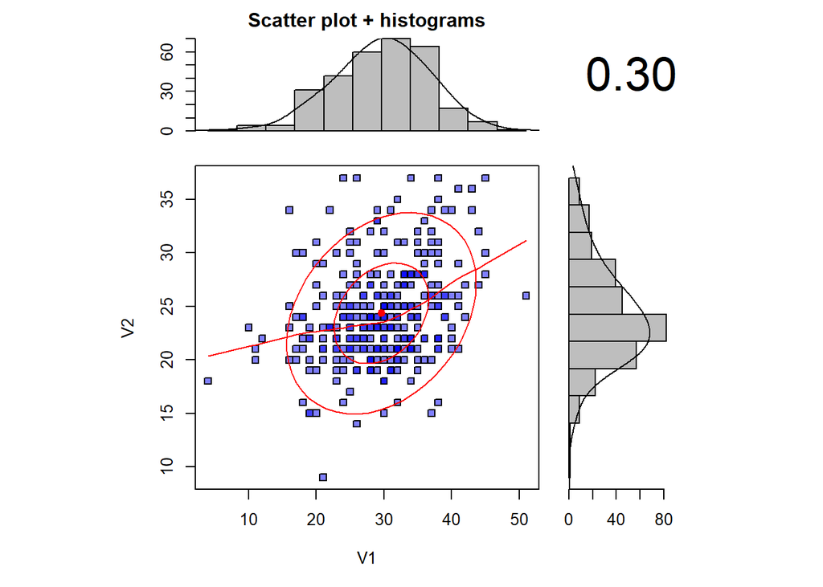

```r
#install.packages('psych')
require(psych)
scatter.hist(x=HS.data$visual,y=HS.data$cubes, density = T, ellipse = T) # bi-variate scatterplot for our data
```

Specification of the model:

```r
detach('package:sem')
fact3<-'
spatial =~ visual + cubes + flags
verbal =~ paragrap + sentence + wordm
speed =~ addition + counting + straight
'

fact3fit<-cfa(fact3, data=HS.data)
summary(fact3fit, fit.measures=TRUE ,standardized=TRUE)
```

```
## lavaan 0.6-7 ended normally after 150 iterations
##
##   Estimator                                         ML
##   Optimization method                           NLMINB
##   Number of free parameters                         21
##
##   Number of observations                           301
##
## Model Test User Model:
##
##   Test statistic                                85.172
##   Degrees of freedom                                24
##   P-value (Chi-square)                           0.000
##
## Model Test Baseline Model:
##
##   Test statistic                               918.592
##   Degrees of freedom                                36
##   P-value                                        0.000
##
## User Model versus Baseline Model:
##
##   Comparative Fit Index (CFI)                    0.931
##   Tucker-Lewis Index (TLI)                       0.896
##
## Loglikelihood and Information Criteria:
##
##   Loglikelihood user model (H0)              -9578.017
##   Loglikelihood unrestricted model (H1)      -9535.431
##
##   Akaike (AIC)                               19198.034
##   Bayesian (BIC)                             19275.883
##   Sample-size adjusted Bayesian (BIC)        19209.283
##
## Root Mean Square Error of Approximation:
##
##   RMSEA                                          0.092
##   90 Percent confidence interval - lower         0.071
##   90 Percent confidence interval - upper         0.114
##   P-value RMSEA <= 0.05                          0.001
```

[output cut: 33 more lines]

```
##
## Variances:
##                    Estimate  Std.Err  z-value  P(>|z|)   Std.lv  Std.all
##    .visual           19.774    4.091    4.833    0.000   19.774    0.404
##    .cubes            18.139    1.628   11.145    0.000   18.139    0.820
##    .flags            54.033    5.801    9.314    0.000   54.033    0.662
##    .paragrap          3.340    0.429    7.778    0.000    3.340    0.275
##    .sentence          7.140    0.934    7.642    0.000    7.140    0.269
##    .wordm            17.455    2.109    8.278    0.000   17.455    0.298
##    .addition        421.390   42.927    9.816    0.000  421.390    0.675
##    .counting        195.314   29.676    6.582    0.000  195.314    0.478
##    .straight        735.487   91.898    8.003    0.000  735.487    0.558
##     spatial          29.127    5.238    5.561    0.000    1.000    1.000
##     verbal            8.816    1.009    8.737    0.000    1.000    1.000
##     speed           202.639   45.503    4.453    0.000    1.000    1.000
```

Explained variance - R2

```r
inspect(fact3fit,'r2') #get r2 for our measured variables
```

```
##   visual    cubes    flags paragrap sentence    wordm addition counting
##    0.596    0.180    0.338    0.725    0.731    0.702    0.325    0.522
## straight
##    0.442
```

Multivariate normality is one of our assumptions. We can check for that using MVN package

```r
#install.packages('MVN')
require(MVN)
test<-mvn(HS.data[,c('visual','cubes','flags','paragrap','sentence','wordm','addition','counting','straight')], mvnTest = 'royston') # multivariate normality for the variables used in our model
test$multivariateNormality
```

```
##      Test   H  p value MVN
## 1 Royston 126 6.65e-23  NO
```

If we do not have multivariate normality, we can calculate robust errors and different test statistic

```r
fact3fitRob<-cfa(fact3, data=HS.data, se='robust.sem',test='satorra.bentler')
summary(fact3fitRob,standardized=TRUE)
```

```
## lavaan 0.6-7 ended normally after 150 iterations
##
##   Estimator                                         ML
##   Optimization method                           NLMINB
##   Number of free parameters                         21
##
##   Number of observations                           301
##
## Model Test User Model:
##                                               Standard      Robust
##   Test Statistic                                85.172      80.756
##   Degrees of freedom                                24          24
##   P-value (Chi-square)                           0.000       0.000
##   Scaling correction factor                                  1.055
##        Satorra-Bentler correction
##
## Parameter Estimates:
##
##   Standard errors                           Robust.sem
##   Information                                 Expected
##   Information saturated (h1) model          Structured
##
## Latent Variables:
##                    Estimate  Std.Err  z-value  P(>|z|)   Std.lv  Std.all
##   spatial =~
##     visual            1.000                               5.397    0.772
##     cubes             0.369    0.069    5.358    0.000    1.992    0.424
##     flags             0.973    0.153    6.364    0.000    5.250    0.581
##   verbal =~
##     paragrap          1.000                               2.969    0.852
##     sentence          1.484    0.089   16.763    0.000    4.406    0.855
##     wordm             2.161    0.139   15.498    0.000    6.416    0.838
##   speed =~
##     addition          1.000                              14.235    0.570
##     counting          1.026    0.132    7.755    0.000   14.611    0.723
##     straight          1.696    0.208    8.170    0.000   24.143    0.665
##
## Covariances:
##                    Estimate  Std.Err  z-value  P(>|z|)   Std.lv  Std.all
##   spatial ~~
##     verbal            7.347    1.480    4.965    0.000    0.459    0.459
##     speed            36.098    7.596    4.752    0.000    0.470    0.470
##   verbal ~~
##     speed            11.991    3.811    3.146    0.002    0.284    0.284
##
## Variances:
##                    Estimate  Std.Err  z-value  P(>|z|)   Std.lv  Std.all
##    .visual           19.774    4.982    3.969    0.000   19.774    0.404
##    .cubes            18.139    1.719   10.552    0.000   18.139    0.820
##    .flags            54.033    5.413    9.981    0.000   54.033    0.662
##    .paragrap          3.340    0.450    7.423    0.000    3.340    0.275
##    .sentence          7.140    0.929    7.689    0.000    7.140    0.269
##    .wordm            17.455    2.267    7.701    0.000   17.455    0.298
##    .addition        421.390   41.596   10.130    0.000  421.390    0.675
##    .counting        195.314   29.691    6.578    0.000  195.314    0.478
##    .straight        735.487   88.246    8.335    0.000  735.487    0.558
##     spatial          29.127    6.024    4.836    0.000    1.000    1.000
##     verbal            8.816    1.087    8.109    0.000    1.000    1.000
##     speed           202.639   43.714    4.636    0.000    1.000    1.000
```

Finally, we can check modification indices and include some of them into our model.

```r
mi <- modindices(fact3fitRob)
mi
```

```
##         lhs op      rhs     mi      epc  sepc.lv sepc.all sepc.nox
## 25  spatial =~ paragrap  1.216    0.038    0.207    0.059    0.059
## 26  spatial =~ sentence  7.446   -0.140   -0.756   -0.147   -0.147
## 27  spatial =~    wordm  2.839    0.130    0.701    0.092    0.092
## 28  spatial =~ addition 18.568   -1.611   -8.697   -0.348   -0.348
## 29  spatial =~ counting  4.192   -0.692   -3.736   -0.185   -0.185
## 30  spatial =~ straight 36.044    3.446   18.600    0.512    0.512
## 31   verbal =~   visual  8.923    0.702    2.083    0.298    0.298
## 32   verbal =~    cubes  0.018   -0.015   -0.045   -0.010   -0.010
## 33   verbal =~    flags  9.162   -0.725   -2.153   -0.238   -0.238
## 34   verbal =~ addition  0.074   -0.139   -0.414   -0.017   -0.017
## 35   verbal =~ counting  3.403   -0.811   -2.407   -0.119   -0.119
## 36   verbal =~ straight  4.693    1.646    4.886    0.135    0.135
## 37    speed =~   visual  0.014    0.006    0.091    0.013    0.013
## 38    speed =~    cubes  1.572   -0.034   -0.490   -0.104   -0.104
```

[output cut: 40 more lines]

Change the model

```r
fact3A<-'
spatial =~ visual + cubes + flags + straight + addition
verbal =~ paragrap + sentence + wordm
speed =~ addition + counting + straight
'

fact3AfitRob<-cfa(fact3A, data=HS.data,se='robust.sem',test='satorra.bentler')
summary(fact3AfitRob, fit.measures=TRUE ,standardized=TRUE)
```

```
## lavaan 0.6-7 ended normally after 200 iterations
##
##   Estimator                                         ML
##   Optimization method                           NLMINB
##   Number of free parameters                         23
##
##   Number of observations                           301
##
## Model Test User Model:
##                                               Standard      Robust
##   Test Statistic                                46.251      44.242
##   Degrees of freedom                                22          22
##   P-value (Chi-square)                           0.002       0.003
##   Scaling correction factor                                  1.045
##        Satorra-Bentler correction
##
## Model Test Baseline Model:
##
##   Test statistic                               918.592     789.304
##   Degrees of freedom                                36          36
##   P-value                                        0.000       0.000
##   Scaling correction factor                                  1.164
##
## User Model versus Baseline Model:
##
##   Comparative Fit Index (CFI)                    0.973       0.970
##   Tucker-Lewis Index (TLI)                       0.955       0.952
##
##   Robust Comparative Fit Index (CFI)                         0.973
##   Robust Tucker-Lewis Index (TLI)                            0.957
##
## Loglikelihood and Information Criteria:
##
##   Loglikelihood user model (H0)              -9558.556   -9558.556
##   Loglikelihood unrestricted model (H1)      -9535.431   -9535.431
##
##   Akaike (AIC)                               19163.112   19163.112
##   Bayesian (BIC)                             19248.376   19248.376
##   Sample-size adjusted Bayesian (BIC)        19175.433   19175.433
##
```

[output cut: 45 more lines]

```
##
## Variances:
##                    Estimate  Std.Err  z-value  P(>|z|)   Std.lv  Std.all
##    .visual           20.990    4.397    4.774    0.000   20.990    0.429
##    .cubes            17.700    1.664   10.635    0.000   17.700    0.801
##    .flags            52.914    4.821   10.976    0.000   52.914    0.649
##    .straight        709.836   81.046    8.758    0.000  709.836    0.538
##    .addition        317.043   59.743    5.307    0.000  317.043    0.508
##    .paragrap          3.366    0.452    7.448    0.000    3.366    0.277
##    .sentence          7.064    0.922    7.663    0.000    7.064    0.266
##    .wordm            17.493    2.271    7.702    0.000   17.493    0.298
##    .counting        193.360   35.564    5.437    0.000  193.360    0.473
##     spatial          27.911    5.407    5.162    0.000    1.000    1.000
##     verbal            8.790    1.087    8.085    0.000    1.000    1.000
##     speed           358.496   94.408    3.797    0.000    1.000    1.000
```

Comparison of the new and original model

```r
diff<-compareFit(fact3fitRob, fact3AfitRob)
summary(diff)
```

```
## ################### Nested Model Comparison #########################
## Scaled Chi-Squared Difference Test (method = "satorra.bentler.2001")
##
## lavaan NOTE:
##     The "Chisq" column contains standard test statistics, not the
##     robust test that should be reported per model. A robust difference
##     test is a function of two standard (not robust) statistics.
##
##              Df   AIC   BIC Chisq Chisq diff Df diff Pr(>Chisq)
## fact3AfitRob 22 19163 19248  46.2
## fact3fitRob  24 19198 19276  85.2       33.6       2    4.9e-08 ***
## ---
## Signif. codes:  0 '***' 0.001 '**' 0.01 '*' 0.05 '.' 0.1 ' ' 1
##
## ####################### Model Fit Indices ###########################
##              chisq.scaled df.scaled pvalue.scaled cfi.robust tli.robust
## fact3AfitRob      44.242†        22          .003      .973†      .957†
## fact3fitRob       80.756         24          .000      .932       .898
##                     aic        bic rmsea.robust  srmr
## fact3AfitRob 19163.112† 19248.376†        .059† .042†
## fact3fitRob  19198.034  19275.883         .091  .065
##
## ################## Differences in Fit Indices #######################
##                            df.scaled cfi.robust tli.robust  aic  bic
## fact3fitRob - fact3AfitRob         2     -0.042     -0.059 34.9 27.5
##                            rmsea.robust  srmr
## fact3fitRob - fact3AfitRob        0.032 0.023
```